# xai5 (1)

### Analiza danych: Medical Expenditure Panel Survey

Cel: predykcja wydatków związanych z leczeniem  
Katarzyna Lorenc

Analiza danych na podstawie Paneli 20 i 21.  
Do poniższej analizy wybrano ręcznie 387 zmiennych, które nie były bezpośrednio związane z wydatkami na leczenie (jak np. wydatki na leczenie stomatologiczne).  
Na tak przygotowanych danych wytrenowany został model **GradientBoostingRegressor**, a następnie ułożyłam zmienne według ich istotności w tym modelu.  
Poniższy wykres prezentuje wartość współczynnika determinacji na zbiorze testowym w zależności od liczby zmiennych.

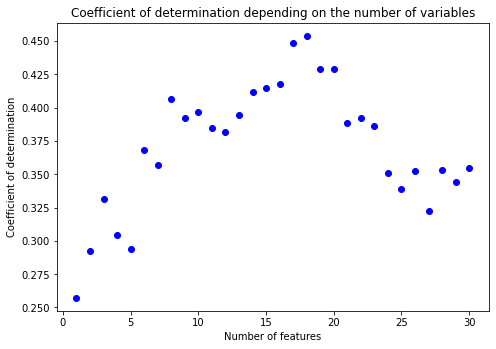

#### Model 1

Wszystkie rozważane modele to **GradientBoostingRegressor**. Model 1 to model zbudowany na nieprzekształconych danych. Usunięto jedynie obserwacje. których wydatki miały wartość *INAPPLICABLE*.

```
Training R^2:  0.7179637469360234
Test R^2:  0.4287308279852471
```

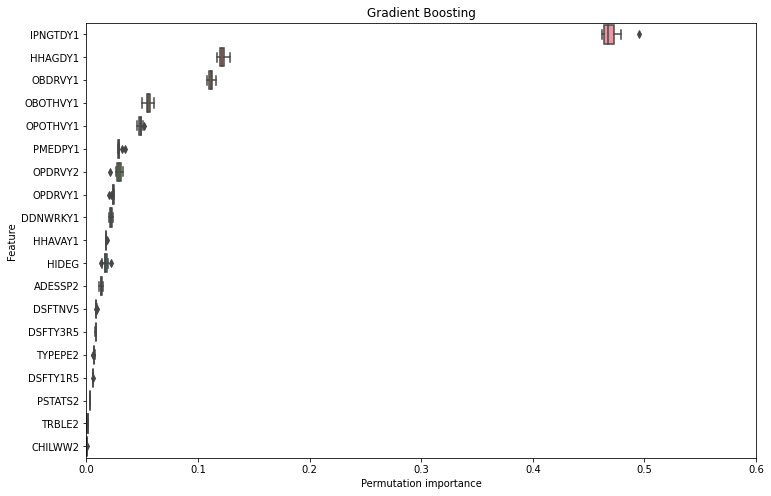

Zmienną, która miała zdecydowanie największy wpływ na wysokość wydatków na leczenie jest liczba nocy spędzonych w szpitalu. Następnie liczba dni, w które pacjent otrzymał opiekę zdrowotną od szpitala lub domu opieki i liczba wizyt u lekarzy.

#### Model 2

W porównaniu z pierwszym modelem, jedyna zmiana to postać zmiennej objaśniającej. W tym przypadku model stara się przewidzieć wartość logarytmu wydatków na leczenie. Wartości współczynnika determinacji są policzone na wartościach przekształconych na pierwotną skalę.

```
Training R^2:  0.6730218154366355
Test R^2:  0.4209371315904902
```

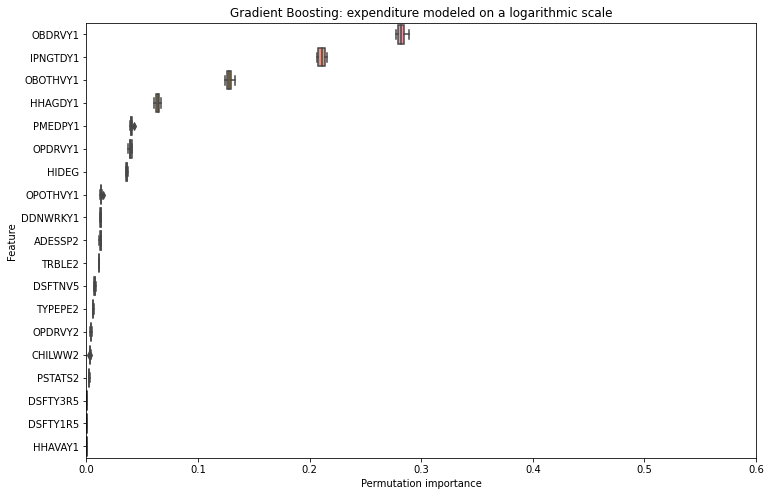

Po zastosowaniu logarytmicznego przekształcenia zmiennej objaśnianej naistotniejsza okazała się zmienna, która oznaczała liczbę wizyt u lekarzy, która w poprzednim modelu znalazła się w rankingu na 3 miejscu. W przypadku obu modeli bardzo istotna okazała się liczba nocy spędzonych w szpitalach.